# statistics

*solution_01_data_basics/05_spread/12_get_IQR_v3*

(ANS = any of [2.86, 3.47, 3.6225, 3.6733333, 4.08, 4.5275, 5.09])

## Method 1: method of medians

This method is described in [the wikipedia page on IQR](https://en.wikipedia.org/wiki/Interquartile_range).

This method relies on first determining the size of each half.

- If the sample size ($n$) is even, divide the sample size by 2.
- If the sample size ($n$) is odd, first subtract 1, then divide the result by 2.

You determine the medians of the lowest half of the values and the highest half of the values. The IQR is the difference of those medians.

In this case, $n=13$, so $Q_1$ is the median of the lowest 6 numbers and $Q_3$ is the median of the highest 6 numbers.

### Method 1 by hand

Method 1 is easiest to do by hand.

$$\text{sort}(\mathbf{x}) = 35.94, 37.47, 38.01, 40.24, 40.92, 42.3, 42.58, 42.89, 43.08, 43.1, 43.31, 44.88, 44.89$$

Because there are 13 values, the first quartile is the median of the lowest 6 values and the third quartile is the median of the highest 6 values.

$$Q_1 = \text{median}(35.94, 37.47, 38.01, 40.24, 40.92, 42.3) = 39.125$$
$$Q_3 = \text{median}(42.89, 43.08, 43.1, 43.31, 44.88, 44.89) = 43.205$$

The IQR is the difference between $Q_3$ and $Q_1$.
$$\text{IQR} = 43.205-39.125 = 4.08$$

### Method 1 with spreadsheet

Unfortunately, the built-in [`QUARTILE` function](https://wiki.openoffice.org/wiki/Documentation/How_Tos/Calc:_QUARTILE_function) does not use the method of medians (more about this in Method 2).

We [sort](https://wiki.openoffice.org/wiki/Documentation/How_Tos/Using_Data_Ranges,_Data_Sort_and_Data_Filters) the data, determine the median of the lowest 6 values, determine the median of the highest 6 values, and take a difference.

You can see a solution spreadsheet.

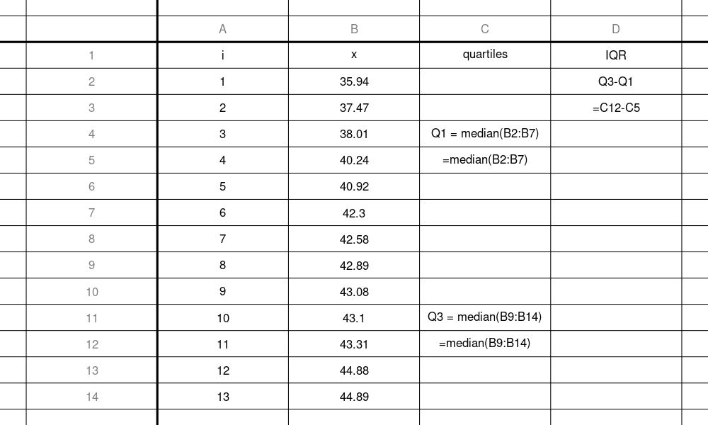

### Method 1 with R

Again, the built-in function does not follow the method of medians. So, Method 1 is actually kind of difficult with R. The following code should be relatively easy to understand… but it uses [floor](https://www.rdocumentation.org/packages/base/versions/3.6.2/topics/Round) rounding, [subsetting](https://www.rdocumentation.org/packages/base/versions/3.6.2/topics/Extract) and [the colon operator](https://www.rdocumentation.org/packages/base/versions/3.6.2/topics/Colon).

```
data = read.csv("get_IQR.csv")
x = data$x
n = length(x)
x_sorted = sort(x)
halfsize = floor(n/2)
Q1 = median(x_sorted[1:halfsize])
Q3 = median(x_sorted[(n-halfsize+1):n])
iqr = Q3-Q1
print(iqr)
```

```
## [1] 4.08
```

## Method 2: built-in functions

### Method 2 with spreadsheet

We can find the quartiles with built-in functions of a spreadsheet.

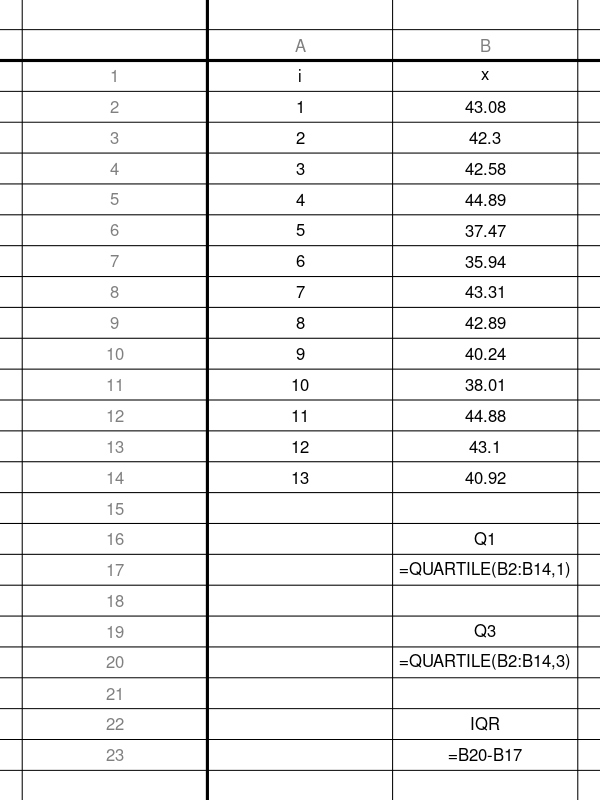

Download this solution

You’ll notice this gives a different answer than Method 1.

### Method 2 with R

There are [9 different built-in methods](https://www.rdocumentation.org/packages/stats/versions/3.6.2/topics/quantile) in R.

```
# Personally, I like the 5th option... the default is 7... some smart researchers suggest 8...
x = read.csv("get_IQR.csv")$x
IQR1 = IQR(x,type=1)
IQR2 = IQR(x,type=2)
IQR3 = IQR(x,type=3)
IQR4 = IQR(x,type=4)
IQR5 = IQR(x,type=5)
IQR6 = IQR(x,type=6)
IQR7 = IQR(x,type=7)
IQR8 = IQR(x,type=8)
IQR9 = IQR(x,type=9)
cat(c(IQR1,IQR2,IQR3,IQR4,IQR5,IQR6,IQR7,IQR8,IQR9))
```

```
## 2.86 2.86 5.09 4.5275 3.47 4.08 2.86 3.673333 3.6225
```

```
#The default is type 7...
x = read.csv("get_IQR.csv")$x
IQR_default = IQR(x)
IQR_default
```

```
## [1] 2.86
```

#### TMI

To really understand what is happening, I think it helps to visualize the quantile functions. Let’s use types 1, 5, and 7. Also, remember the sorted sample:

```
## 35.94 37.47 38.01 40.24 40.92 42.3 42.58 42.89 43.08 43.1 43.31 44.88 44.89
```

Type 1 is based on the [empirical cumululative distribution](https://en.wikipedia.org/wiki/Empirical_distribution_function).

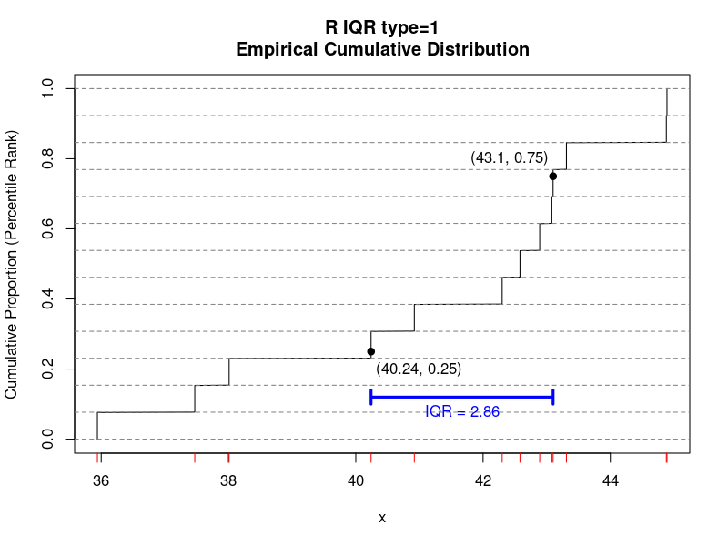

Types 5 and 7 are based on continuous versions of the empirical cumulative distribution.

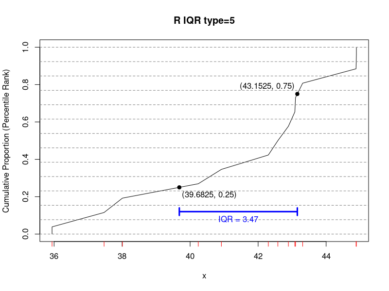

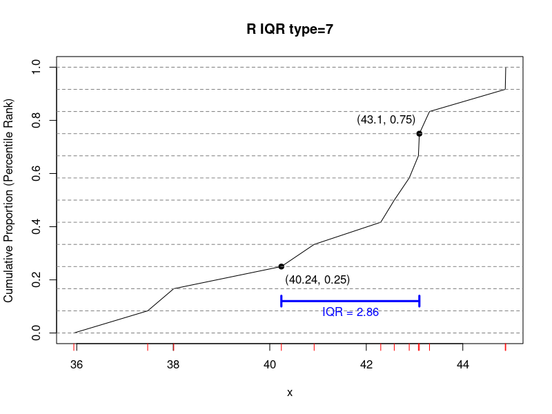

## TL;DR

Any of the following answers are accepted:

```
## 4.08 2.86 2.86 2.86 5.09 4.5275 3.47 4.08 2.86 3.673333 3.6225
```